# trabajo_grupal

#### Normalizacion de variables

```r
#Creamos una funcion para normalizar
normalize <- function(x) {
return((x - min(x)) / (max(x) - min(x)))
}

#normalizamos la columna edad
titanic_transform$Age_norm <- normalize(titanic_transform$Age)

#eliminamos la columna Age original dejando solo la normalizada
titanic_transform$Age <- NULL
```

```r
# Normalizamos Fare pero antes quitamos los na que tiene 1
titanic_transform <- titanic_transform[!is.na(titanic_transform$Fare), ]
titanic_transform$Fare_norm <- normalize(titanic_transform$Fare)

#eliminamos la columna head original dejando solo la normalizada
titanic_transform$Fare <- NULL
head(titanic_transform, 10)
```

```
##    PassengerId Survived Pclass
## 1            1        0      3
## 2            2        1      1
## 3            3        1      3
## 4            4        1      1
## 5            5        0      3
## 6            6        0      3
## 7            7        0      1
## 8            8        0      3
## 9            9        1      3
## 10          10        1      2
##                                                   Name Sex SibSp Parch
## 1                              Braund, Mr. Owen Harris   1     1     0
## 2  Cumings, Mrs. John Bradley (Florence Briggs Thayer)   0     1     0
## 3                               Heikkinen, Miss. Laina   0     0     0
```

[output cut: 29 more lines]

#### Algunas visualizaciones en exploracion de datos

#### Ver relación entre el sexo y los supervivientes

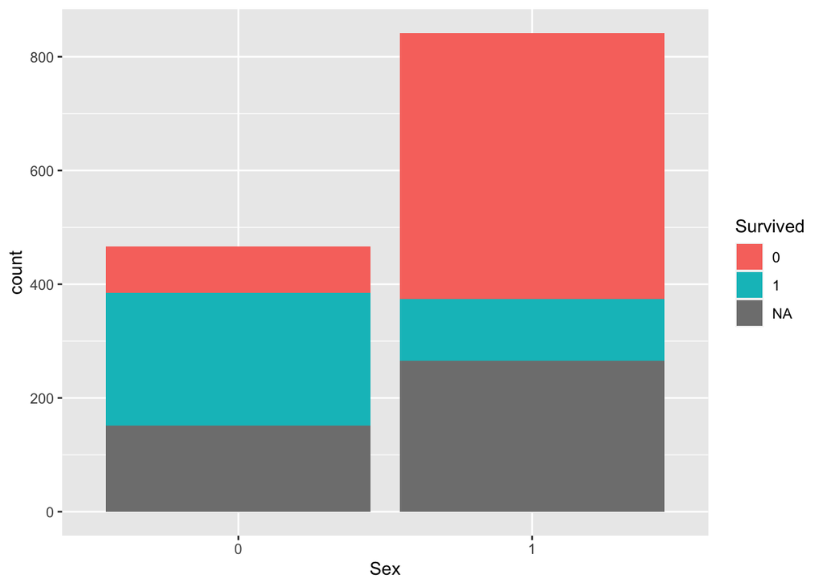

```r
titanic_transform$Survived <- as.factor(titanic_transform$Survived)
ggplot(data = titanic_transform[], aes(x = Sex, fill = Survived)) + geom_bar()
```

#### Ver relación entre la puerta de embarque y los supervivientes

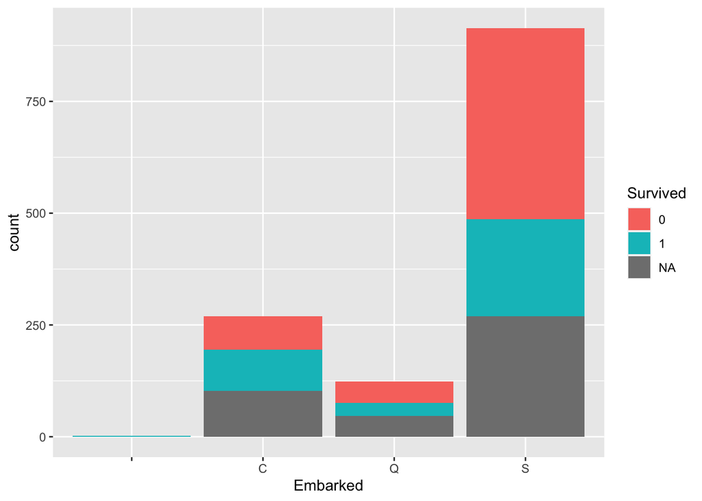

```r
titanic$Survived <- as.factor(titanic$Survived)
ggplot(data = titanic[], aes(x = Embarked, fill = Survived)) + geom_bar()
```

#### Ver relación entre la clase y los supervivientes

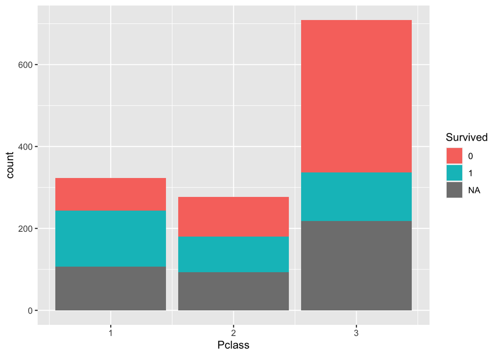

```r
ggplot(data = titanic[], aes(x = Pclass, fill = Survived)) + geom_bar()
```

#### Conclusiones

Se ha realizado una exploración y transformacion general de las variables oportunas. En caso de derivar el dataset para un proceso de aprendizaje automático se seguiría analizando si es necesario transformas más varibales(normalización, codificación, eliminación, etc.).

### Ejercicio 2: Presentación del paquete TM

### A continuación, se presenta el paquete TM para minería de Texto.

#### 1 - Comenzamos con la instalación y carga de los paquetes necesarios: tm y wordcloud.

```r
install.packages("tm")
```

```r
library(tm)

install.packages("wordcloud")
library(wordcloud)
install.packages("ggplot2")
library(ggplot2)
```

#### 2 - Vamos a generar un corpus con los documentos que se van a analizar y transformar:

Los documentos a analizar tendrán formato PDF y deben estar en el directorio ./papers desde el que se ejecuta este Notebook.

```r
getwd()
```

```
## [1] "/Users/runner/work/devR-grupo3/devR-grupo3"
```

```r
#Los documentos (pdf) deben estar en el directorio ./papers

# Generamos una lista con lo nombres de los ficheros pdf en ./papers

papers <- list.files(path = "./papers", pattern = "pdf$")
papers <- lapply(papers, paste)

#Comprobamos que detectan los documentos

papers <- paste("./papers/", papers, sep = "")
```

Podemos ver la lista de documentos que se van a incorporar al corpus.

```r
papers
```

```
## [1] "./papers/staa158.pdf"
## [2] "./papers/stab2082_230128_113648.pdf"
## [3] "./papers/The_First_Post_Kepler_Brightness_Dips_of_KIC_8462852.pdf"
## [4] "./papers/Usher_2020_Planet._Sci._J._1_84.pdf"
```

En el siguiente paso se crea el corpus incorporando los documentos pdf existentes en el directorio.

Los documentos se transforman en texto plano.

```r
#procedemos a crear el corpus con los documentos en texto obtenidos de los pdfs

corp <- Corpus(URISource(papers),
               readerControl = list(reader = readPDF))
```

Mostramos el contenido del corpus y las características de cada documento:

```r
#Inspeccionamos el contenido del corpus mostrando para cada documento
#número de metadatos y el número de carácteres de cada doc
inspect(corp)
```

```
## <<VCorpus>>
## Metadata:  corpus specific: 0, document level (indexed): 0
## Content:  documents: 4
##
## [[1]]
## <<PlainTextDocument>>
## Metadata:  7
## Content:  chars: 111213
##
## [[2]]
## <<PlainTextDocument>>
## Metadata:  7
## Content:  chars: 96591
##
## [[3]]
## <<PlainTextDocument>>
## Metadata:  7
## Content:  chars: 115363
##
## [[4]]
## <<PlainTextDocument>>
## Metadata:  7
## Content:  chars: 117174
```

Podemos visualizar los metadatos de cada documento recorriendo el corpus con un bucle for:

```r
#Visualizamos los metadatos de cada uno de los documentos
for (i in seq_along(corp)) {
print(meta(corp[[i]]))
}
```

```
##   author       :
##   datetimestamp: 2020-02-14 02:09:40
##   description  :
##   heading      :
##   id           : staa158.pdf
##   language     : en
##   origin       : LaTeX with hyperref package
##   author       : character(0)
##   datetimestamp: 2106-02-07 06:28:15
##   description  : character(0)
##   heading      : character(0)
##   id           : stab2082_230128_113648.pdf
##   language     : en
##   origin       : Samsung Electronics
##   author       : Tabetha. S. Boyajian
##   datetimestamp: 2018-01-19 05:36:06
##   description  : The Astrophysical Journal Letters, 853(2018) L8. doi:10.3847/2041-8213/aaa405
##   heading      : The First Post-Kepler Brightness Dips of KIC 8462852
##   id           : The_First_Post_Kepler_Brightness_Dips_of_KIC_8462852.pdf
##   language     : en
##   origin       : IOPP
##   author       : Helen Usher
##   datetimestamp: 2020-12-28 15:22:56
##   description  : The Planetary Science Journal, 1(2020) 84. doi:10.3847/PSJ/abca46
##   heading      : Seeing the Bigger Picture: Rosetta Mission Amateur Observing Campaign and Lessons for the Future
##   id           : Usher_2020_Planet._Sci._J._1_84.pdf
##   language     : en
##   origin       : IOPP
```

```r
dtm <- DocumentTermMatrix(corp)
```

#### 3 - Comenzamos con el análisis de los documentos.

Primero vamos a generar la mátriz del corpus **(DocumentTermMatrix)** y las estadísticas de esta:

- Número de documentos
- Número de términos.
- Dispersión.
- Máxima longitud o máximo número de carácteres para un término.

```r
#Creamos la Mátriz de términos
dtm <- DocumentTermMatrix(corp)

#Visualizamos las estádisticas
dtm
```

```
## <<DocumentTermMatrix (documents: 4, terms: 10299)>>
## Non-/sparse entries: 13892/27304
## Sparsity           : 66%
## Maximal term length: 70
## Weighting          : term frequency (tf)
```

#### 4 - Vamos a transformar los documentos del corpus para realizar un mejor análisis.

Se va a reducir el número de términos mediante el siguiente proceso:

1. Eliminamos los números ya que se consideran términos y no van a ser objeto del análisis.
2. Quitamos los signos de puntuación.
3. Se convierte el texto a minúsculas ya que TM es sensible a las mayúsculas.
4. Eliminamos las palabras sin significado relevante para el análisis: preposiciones, conjunciones (stopwords).
5. Eliminamos espacios redundantes

```r
#Para reducir el volumen de términos y quedarnos solo con las palabras
#clave:

#1) Eliminamos los números (no son objeto del análisis)
corp <- tm_map(corp, removeNumbers)

#2) eliminamos los signos de puntuación
corp <- tm_map(corp, removePunctuation)

#pasamos el texto a minúsculas
corp <- tm_map(corp, content_transformer(tolower))

#Eliminamos las palabras comunes como artículo y preposiciones en inglés
corp <- tm_map(corp, removeWords, stopwords(kind = "en"))

#Eliminamos espacios consecutivos
corp <- tm_map(corp, stripWhitespace)
```

Volvemos a visualizar las estadísticas: El número de términos y la dispersión han debido reducirse al eliminar los elementos anteriores.

```r
#Volvemos a generar la Matriz de términos y visualizamos estadísticas
dtm <- DocumentTermMatrix(corp)
dtm
```

```
## <<DocumentTermMatrix (documents: 4, terms: 5634)>>
## Non-/sparse entries: 8519/14017
## Sparsity           : 62%
## Maximal term length: 54
## Weighting          : term frequency (tf)
```

Presentamos el histograma de términos más frecuentes en el corpus:

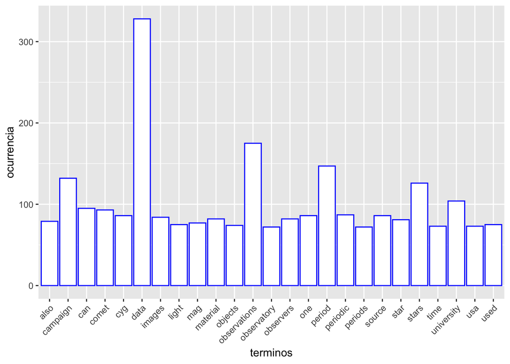

```r
frec <- sort(colSums(as.matrix(dtm)), decreasing = TRUE)
df <- data.frame(terminos = names(frec), ocurrencia = frec)

p <- ggplot(subset(df, frec > 70), aes(terminos, ocurrencia))
p <- p + scale_fill_brewer(palette = "Blues")
p <- p + geom_bar(stat = "identity", color = "blue", fill = "white")
p <- p + theme(axis.text.x = element_text(angle = 45, hjust = 1))
p
```

#### 5 - Vamos a representar la nube de palabras del corpus:

Para ello utilizaremos una nube de palabras generada por la librería **wordcloud**

El proceso es el siguiente:

1. Calculamos para cada término de la matriz la suma total de apariciones (para todo el corpus).
2. Se ordena de forma de mayor a menor frecuencia.
3. Se selecciona un número máximo de palabras (30 en este caso)
4. Se dibuja la nube de palabras mediante la función wordcloud.

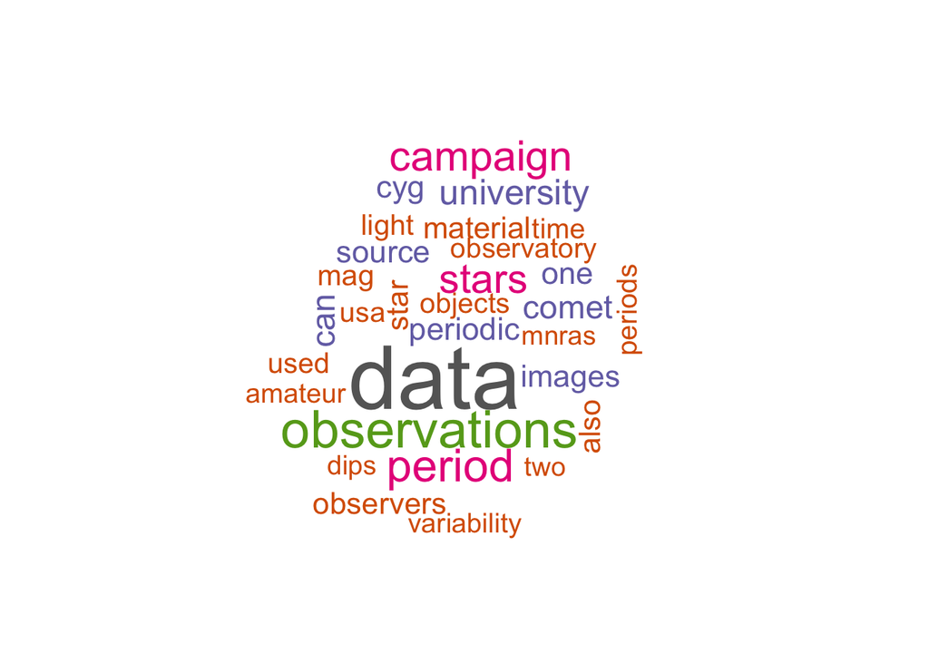

```r
set.seed(16)
wordcloud(names(frec), frec, min.freq = 10, max.words = 30
          , colors = brewer.pal(8, "Dark2"))
```

### Ejercicio 3: Estudio y presentación de dataset cáncer

**Cargamos los datos del dataset cáncer**

```r
df_cancer <- fread(paste0(data_link, "Breast_Cancer.csv"), sep = ",", dec = ".")
head(df_cancer, 10)
```

```
##     Age  Race Marital Status T Stage N Stage 6th Stage
##  1:  68 White        Married      T1      N1       IIA
##  2:  50 White        Married      T2      N2      IIIA
##  3:  58 White       Divorced      T3      N3      IIIC
##  4:  58 White        Married      T1      N1       IIA
##  5:  47 White        Married      T2      N1       IIB
##  6:  51 White         Single      T1      N1       IIA
##  7:  51 White        Married      T1      N1       IIA
##  8:  40 White        Married      T2      N1       IIB
##  9:  40 White       Divorced      T4      N3      IIIC
## 10:  69 White        Married      T4      N3      IIIC
##                 differentiate Grade  A Stage Tumor Size Estrogen Status
##  1:     Poorly differentiated     3 Regional          4        Positive
##  2: Moderately differentiated     2 Regional         35        Positive
##  3: Moderately differentiated     2 Regional         63        Positive
```

[output cut: 29 more lines]

**Vemos la estructura del dataframe**

```r
str(df_cancer)
```

```
## Classes 'data.table' and 'data.frame':   4024 obs. of  16 variables:
##  $ Age                   : int  68 50 58 58 47 51 51 40 40 69 ...
##  $ Race                  : chr  "White" "White" "White" "White" ...
##  $ Marital Status        : chr  "Married" "Married" "Divorced" "Married" ...
##  $ T Stage               : chr  "T1" "T2" "T3" "T1" ...
##  $ N Stage               : chr  "N1" "N2" "N3" "N1" ...
##  $ 6th Stage             : chr  "IIA" "IIIA" "IIIC" "IIA" ...
##  $ differentiate         : chr  "Poorly differentiated" "Moderately differentiated" "Moderately differentiated" "Poorly differentiated" ...
##  $ Grade                 : chr  "3" "2" "2" "3" ...
##  $ A Stage               : chr  "Regional" "Regional" "Regional" "Regional" ...
##  $ Tumor Size            : int  4 35 63 18 41 20 8 30 103 32 ...
##  $ Estrogen Status       : chr  "Positive" "Positive" "Positive" "Positive" ...
##  $ Progesterone Status   : chr  "Positive" "Positive" "Positive" "Positive" ...
##  $ Regional Node Examined: int  24 14 14 2 3 18 11 9 20 21 ...
##  $ Reginol Node Positive : int  1 5 7 1 1 2 1 1 18 12 ...
##  $ Survival Months       : int  60 62 75 84 50 89 54 14 70 92 ...
##  $ Status                : chr  "Alive" "Alive" "Alive" "Alive" ...
##  - attr(*, ".internal.selfref")=<externalptr>
```

**Resumen de las caracteristicas de las variables del dataframe**

```r
summary(df_cancer)
```

```
##       Age            Race           Marital Status       T Stage
##  Min.   :30.00   Length:4024        Length:4024        Length:4024
##  1st Qu.:47.00   Class :character   Class :character   Class :character
##  Median :54.00   Mode  :character   Mode  :character   Mode  :character
##  Mean   :53.97
##  3rd Qu.:61.00
##  Max.   :69.00
##    N Stage           6th Stage         differentiate         Grade
##  Length:4024        Length:4024        Length:4024        Length:4024
##  Class :character   Class :character   Class :character   Class :character
##  Mode  :character   Mode  :character   Mode  :character   Mode  :character
##
##
##
##    A Stage            Tumor Size     Estrogen Status    Progesterone Status
##  Length:4024        Min.   :  1.00   Length:4024        Length:4024
##  Class :character   1st Qu.: 16.00   Class :character   Class :character
##  Mode  :character   Median : 25.00   Mode  :character   Mode  :character
##                     Mean   : 30.47
##                     3rd Qu.: 38.00
##                     Max.   :140.00
##  Regional Node Examined Reginol Node Positive Survival Months
##  Min.   : 1.00          Min.   : 1.000        Min.   :  1.0
##  1st Qu.: 9.00          1st Qu.: 1.000        1st Qu.: 56.0
##  Median :14.00          Median : 2.000        Median : 73.0
##  Mean   :14.36          Mean   : 4.158        Mean   : 71.3
##  3rd Qu.:19.00          3rd Qu.: 5.000        3rd Qu.: 90.0
##  Max.   :61.00          Max.   :46.000        Max.   :107.0
##     Status
##  Length:4024
##  Class :character
##  Mode  :character
##
##
##
```

**Vemos si el dataframe tiene Na**

```r
# Exploramos las primeras 10 lineas del df para ver si hay algún TRUE
head(is.na(df_cancer), 10)
```

```
##         Age  Race Marital Status T Stage N Stage 6th Stage differentiate Grade
##  [1,] FALSE FALSE          FALSE   FALSE   FALSE     FALSE         FALSE FALSE
##  [2,] FALSE FALSE          FALSE   FALSE   FALSE     FALSE         FALSE FALSE
##  [3,] FALSE FALSE          FALSE   FALSE   FALSE     FALSE         FALSE FALSE
##  [4,] FALSE FALSE          FALSE   FALSE   FALSE     FALSE         FALSE FALSE
##  [5,] FALSE FALSE          FALSE   FALSE   FALSE     FALSE         FALSE FALSE
##  [6,] FALSE FALSE          FALSE   FALSE   FALSE     FALSE         FALSE FALSE
##  [7,] FALSE FALSE          FALSE   FALSE   FALSE     FALSE         FALSE FALSE
##  [8,] FALSE FALSE          FALSE   FALSE   FALSE     FALSE         FALSE FALSE
##  [9,] FALSE FALSE          FALSE   FALSE   FALSE     FALSE         FALSE FALSE
## [10,] FALSE FALSE          FALSE   FALSE   FALSE     FALSE         FALSE FALSE
##       A Stage Tumor Size Estrogen Status Progesterone Status
##  [1,]   FALSE      FALSE           FALSE               FALSE
##  [2,]   FALSE      FALSE           FALSE               FALSE
##  [3,]   FALSE      FALSE           FALSE               FALSE
```

[output cut: 18 more lines]

```r
# Vemos la posición en la que hay nulls, si los hay
print("-------------------------------------------------------")
```

```
## [1] "-------------------------------------------------------"
```

```r
apply(is.na(df_cancer), 2, which) # No tiene Na
```

```
## integer(0)
```

**Obtenemos los valores únicos de las variables**

```r
unique(df_cancer$Age)
```

```
##  [1] 68 50 58 47 51 40 69 46 65 48 62 61 56 43 60 57 55 63 66 53 59 54 49 64 42
## [26] 37 67 31 52 33 45 38 39 36 41 44 32 34 35 30
```

```r
unique(df_cancer$Race)
```

```
## [1] "White" "Black" "Other"
```

```r
unique(df_cancer$`Marital Status`)
```

```
## [1] "Married"   "Divorced"  "Single"    "Widowed"   "Separated"
```

```r
unique(df_cancer$`T Stage`)
```

```
## [1] "T1" "T2" "T3" "T4"
```

```r
unique(df_cancer$`N Stage`)
```

```
## [1] "N1" "N2" "N3"
```

```r
unique(df_cancer$`6th Stage`)
```

```
## [1] "IIA"  "IIIA" "IIIC" "IIB"  "IIIB"
```

```r
unique(df_cancer$differentiate)
```

```
## [1] "Poorly differentiated"     "Moderately differentiated"
## [3] "Well differentiated"       "Undifferentiated"
```

```r
unique(df_cancer$Grade)
```

```
## [1] "3"                    "2"                    "1"
## [4] "anaplastic; Grade IV"
```

```r
unique(df_cancer$`A Stage`)
```

```
## [1] "Regional" "Distant"
```

```r
unique(df_cancer$`Tumor Size`)
```

```
##   [1]   4  35  63  18  41  20   8  30 103  32  13  59  15  19  46  24  25  29
##  [19]  40  70  22  50  17  21  10  27  23   5  51   9  55 120  77   2  11  12
##  [37]  26  75 130  34  80   3  60  14  16  45  36  76  38  49   7  72 100  43
##  [55]  62  37  68  52  85  57  39  28  48 110  65   6 105 140  42  31  90 108
##  [73]  98  47  54  61  74  33   1  87  81  58 117  44 123 133  95 107  92  69
##  [91]  56  82  66  78  97  88  53  83 101  84 115  73 125 104  94  86  64  96
## [109]  79  67
```

```r
unique(df_cancer$`Estrogen Status`)
```

```
## [1] "Positive" "Negative"
```

```r
unique(df_cancer$`Progesterone Status`)
```

```
## [1] "Positive" "Negative"
```

```r
unique(df_cancer$`Regional Node Examined`)
```

```
##  [1] 24 14  2  3 18 11  9 20 21 13 23 16  1 22 15  4 26 31 25 10  5  6 19 12  8
## [26] 17  7 49 33 30 34 28 32 27 42 29 41 39 46 40 51 44 38 47 54 36 61 37 35 43
## [51] 52 45 57 60
```

```r
unique(df_cancer$`Reginol Node Positive`)
```

```
##  [1]  1  5  7  2 18 12  3 14 22 17 23  4 10  6  9  8 20 16 13 11 24 27 21 26 15
## [26] 28 19 29 31 46 33 37 30 35 25 32 41 34
```

```r
unique(df_cancer$`Survival Months`)
```

```
##   [1]  60  62  75  84  50  89  54  14  70  92  64  56  38  49 105 107  77  81
##  [19]  78 102  98  82  86  52  90  31  37 103  42  61  63  39  59  71  74  73
##  [37]  91 106  80  44  85  79 104  12  95  55 101  65  72  57  87  40  25   8
##  [55]  53  58  24  66  69  93  94 100  96  41  67  51  13  11  47  23  45  68
##  [73]  76  15  16  99   7  48  88  34  97  83  17   3  22  30   6  32   9   5
##  [91]  10  19  18  35  27  36   4  29  33  26  20  28  43   1  46  21   2
```

```r
unique(df_cancer$Status)
```

```
## [1] "Alive" "Dead"
```

**Se reemplaza el valor del grado desacorde por 4**

```r
df_cancer$Grade[df_cancer$Grade == "anaplastic; Grade IV"] <- "4"
df_cancer$Grade <- as.integer(df_cancer$Grade)
```

**Vemos si el dataframe tiene datos duplicados**

```r
# El df tiene una fila duplicada
df_cancer[duplicated(df_cancer)]
```

```
##    Age  Race Marital Status T Stage N Stage 6th Stage             differentiate
## 1:  63 White        Married      T1      N1       IIA Moderately differentiated
##    Grade  A Stage Tumor Size Estrogen Status Progesterone Status
## 1:     2 Regional         17        Positive            Positive
##    Regional Node Examined Reginol Node Positive Survival Months Status
## 1:                      9                     1              56  Alive
```

```r
# Borramos la fila duplicada
head(df_cancer[!duplicated(df_cancer)], 10)
```

```
##     Age  Race Marital Status T Stage N Stage 6th Stage
##  1:  68 White        Married      T1      N1       IIA
##  2:  50 White        Married      T2      N2      IIIA
##  3:  58 White       Divorced      T3      N3      IIIC
##  4:  58 White        Married      T1      N1       IIA
##  5:  47 White        Married      T2      N1       IIB
##  6:  51 White         Single      T1      N1       IIA
##  7:  51 White        Married      T1      N1       IIA
##  8:  40 White        Married      T2      N1       IIB
##  9:  40 White       Divorced      T4      N3      IIIC
## 10:  69 White        Married      T4      N3      IIIC
##                 differentiate Grade  A Stage Tumor Size Estrogen Status
##  1:     Poorly differentiated     3 Regional          4        Positive
##  2: Moderately differentiated     2 Regional         35        Positive
##  3: Moderately differentiated     2 Regional         63        Positive
```

[output cut: 29 more lines]

**Cambiar el valor de la variable Status a numerico**

```r
# Si sobrevive asignamos un 1 y si se muere es un 0
df_cancer$Status <- c(Alive = 1, Dead = 0)[df_cancer$Status]
unique(df_cancer$Status)
```

```
## [1] 1 0
```

```r
head(df_cancer, 10)
```

```
##     Age  Race Marital Status T Stage N Stage 6th Stage
##  1:  68 White        Married      T1      N1       IIA
##  2:  50 White        Married      T2      N2      IIIA
##  3:  58 White       Divorced      T3      N3      IIIC
##  4:  58 White        Married      T1      N1       IIA
##  5:  47 White        Married      T2      N1       IIB
##  6:  51 White         Single      T1      N1       IIA
##  7:  51 White        Married      T1      N1       IIA
##  8:  40 White        Married      T2      N1       IIB
##  9:  40 White       Divorced      T4      N3      IIIC
## 10:  69 White        Married      T4      N3      IIIC
##                 differentiate Grade  A Stage Tumor Size Estrogen Status
##  1:     Poorly differentiated     3 Regional          4        Positive
##  2: Moderately differentiated     2 Regional         35        Positive
##  3: Moderately differentiated     2 Regional         63        Positive
```

[output cut: 29 more lines]

**Conteo de variables**

```r
# Conteo para cada raza y grado
table(df_cancer$Race, df_cancer$Grade)
```

```
##
##            1    2    3    4
##   Black   32  141  115    3
##   Other   46  180   94    0
##   White  465 2030  902   16
```

Se puede apreciar que la raza blanca tiene sobretodo cáncer en grado 2

```r
# Conteo para cada estado marital y los meses de supervivencia
table(df_cancer$`Marital Status`, df_cancer$Grade)
```

```
##
##                1    2    3    4
##   Divorced    52  288  145    1
##   Married    365 1569  698   11
##   Separated    8   24   12    1
##   Single      77  342  191    5
##   Widowed     41  128   65    1
```

Se sigue apreciando que los que tienen un conteo mayor son los casados en estadio 2

**Correlacion con las variables numéricas**

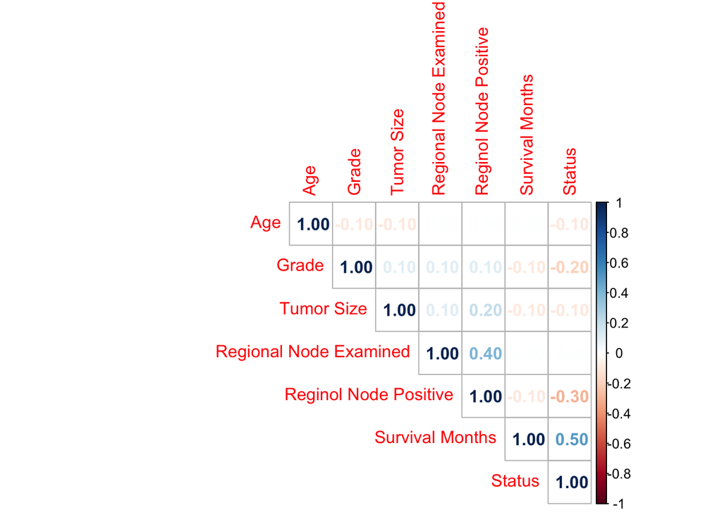

```r
base <- df_cancer[, c("Age", "Grade", "Tumor Size", "Regional Node Examined",
                      "Reginol Node Positive", "Survival Months", "Status")]
correlacion <- round(cor(base), 1)
corrplot(correlacion, method = "number", type = "upper")
```

```r
cor(df_cancer$Age, df_cancer$Status, method =
      c("pearson", "kendall", "spearman"))
```

```
## [1] -0.05592131
```

```r
cor(df_cancer$`Tumor Size`, df_cancer$Status, method =
      c("pearson", "kendall", "spearman"))
```

```
## [1] -0.1342051
```

**Visualizaciones de las distintas variables del dataset contra el estado del paciente por cada valor de las variables*

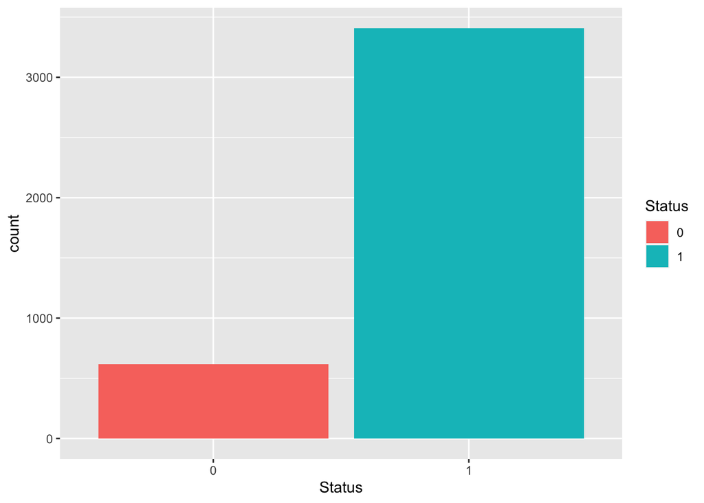

```r
df_cancer$Status <- as.factor(df_cancer$Status)
df_cancer %>% ggplot(aes(Status, fill = Status)) + geom_bar()
```

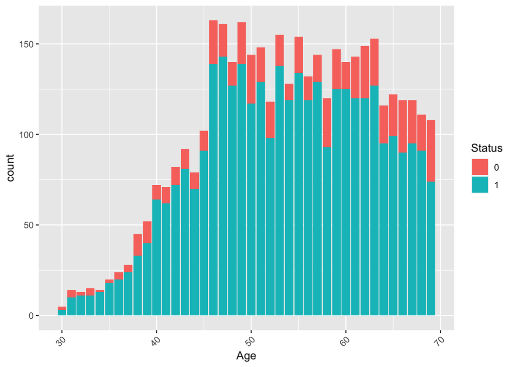

```r
df_cancer %>% ggplot(aes(Age, fill = Status)) + geom_bar() +
  theme(axis.text.x = element_text(angle = 45, hjust = 1))
```

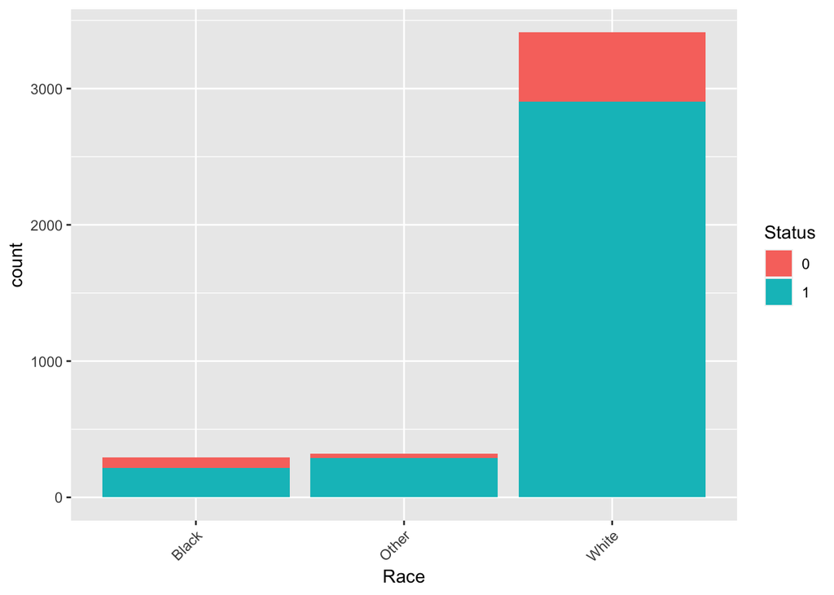

```r
df_cancer %>% ggplot(aes(Race, fill = Status)) + geom_bar() +
  theme(axis.text.x = element_text(angle = 45, hjust = 1))
```

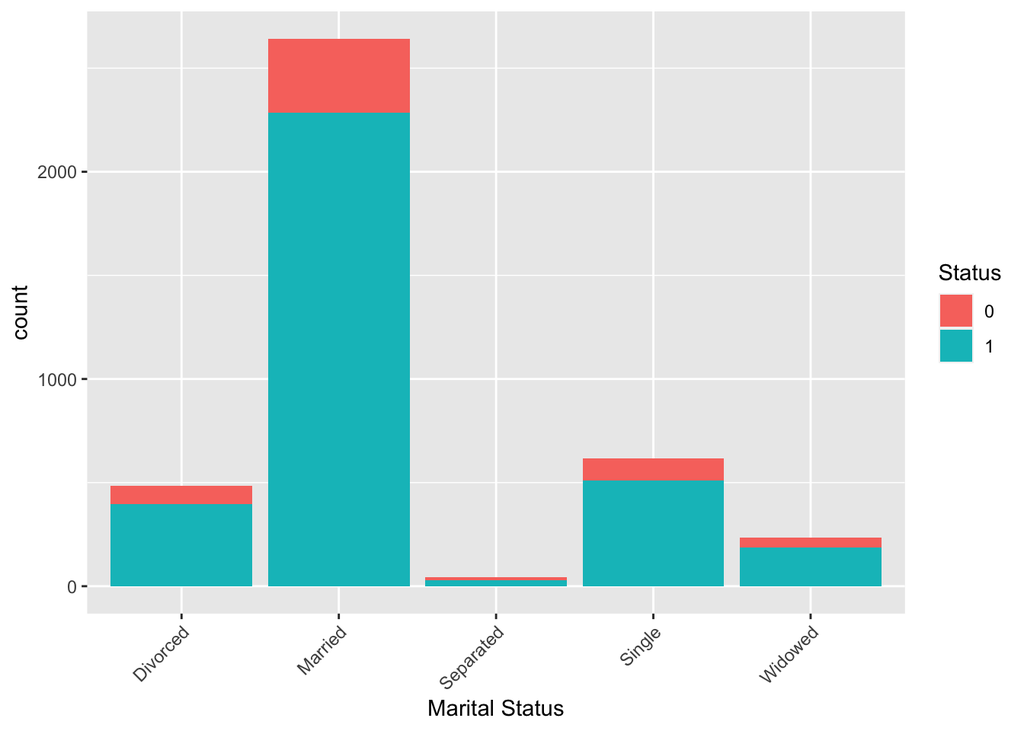

```r
df_cancer %>% ggplot(aes(`Marital Status`, fill = Status)) + geom_bar() +
  theme(axis.text.x = element_text(angle = 45, hjust = 1))
```

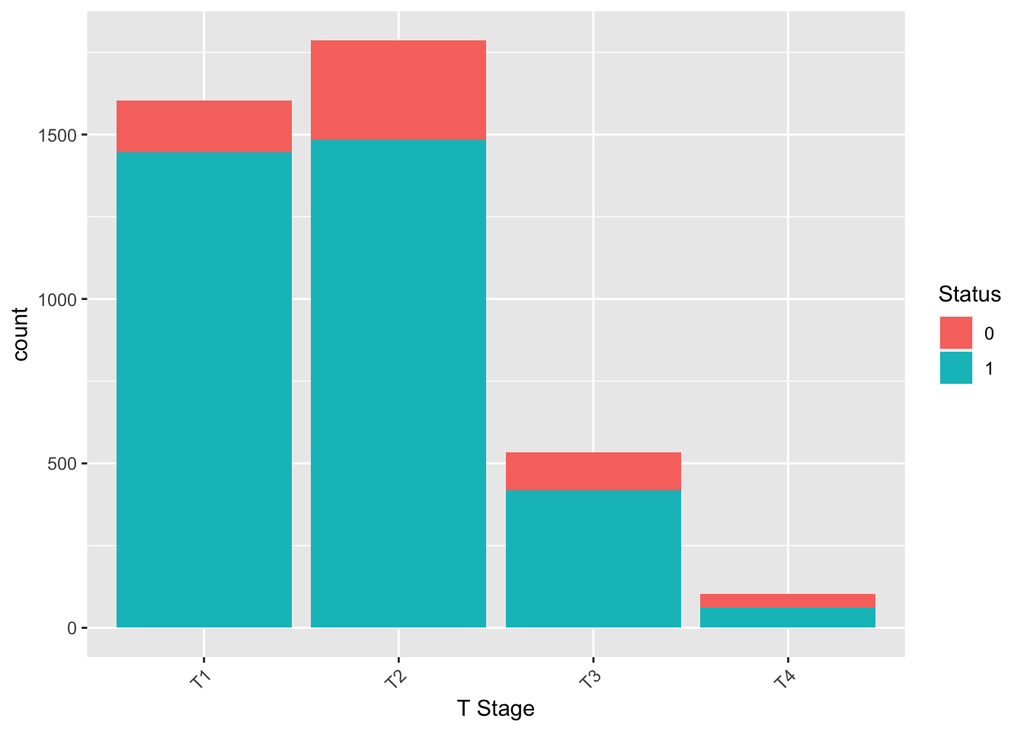

```r
df_cancer %>% ggplot(aes(`T Stage`, fill = Status)) + geom_bar() +
  theme(axis.text.x = element_text(angle = 45, hjust = 1))
```

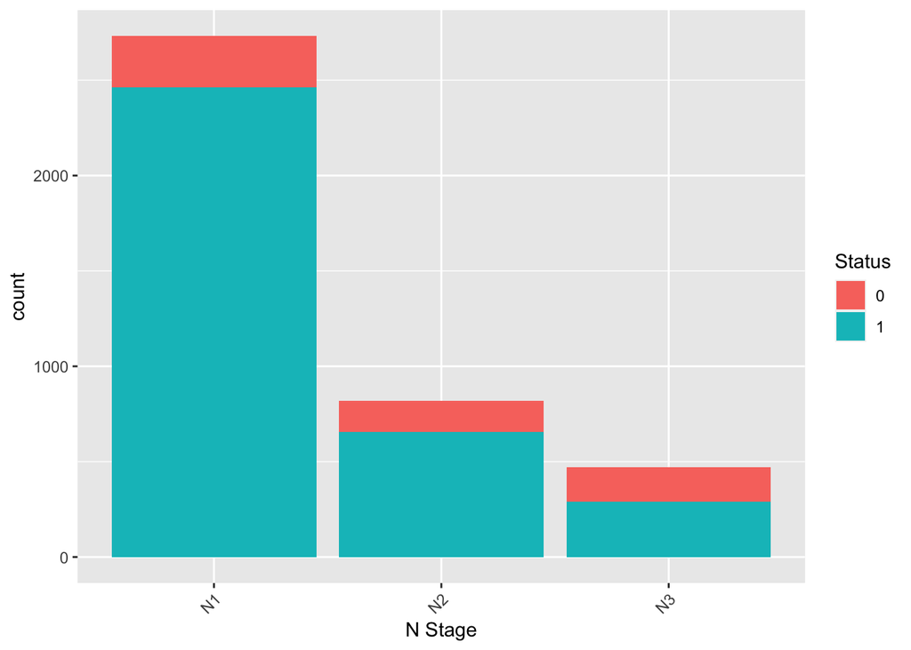

```r
df_cancer %>% ggplot(aes(`N Stage`, fill = Status)) + geom_bar() +
  theme(axis.text.x = element_text(angle = 45, hjust = 1))
```

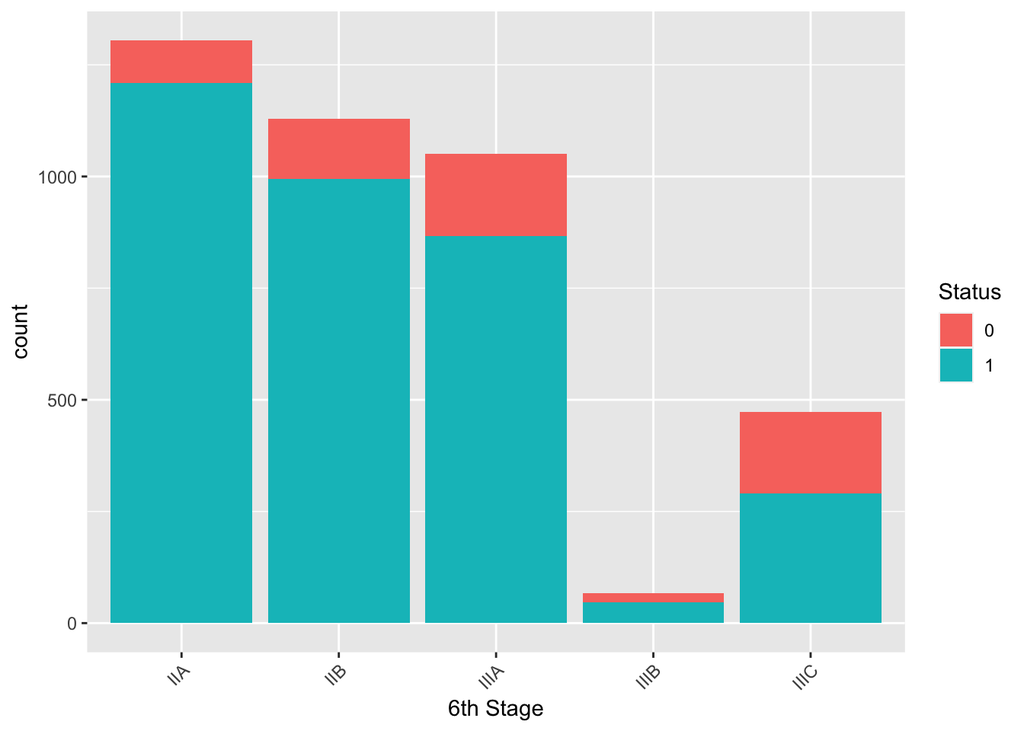

```r
df_cancer %>% ggplot(aes(`6th Stage`, fill = Status)) + geom_bar() +
  theme(axis.text.x = element_text(angle = 45, hjust = 1))
```

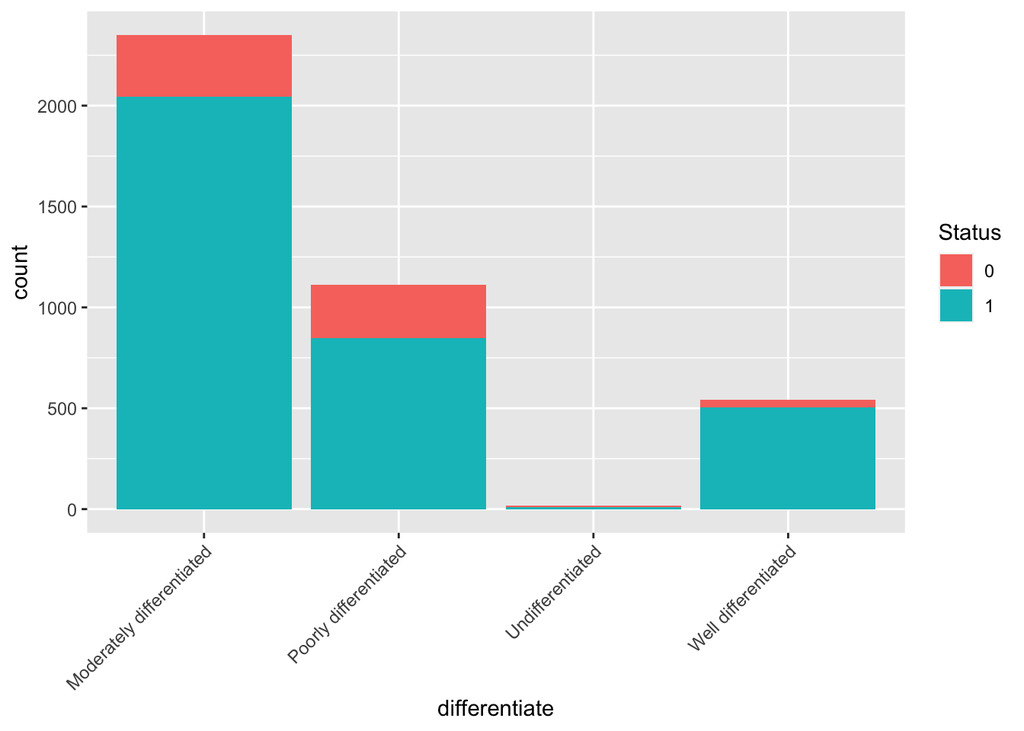

```r
df_cancer %>% ggplot(aes(differentiate, fill = Status)) + geom_bar() +
  theme(axis.text.x = element_text(angle = 45, hjust = 1))
```

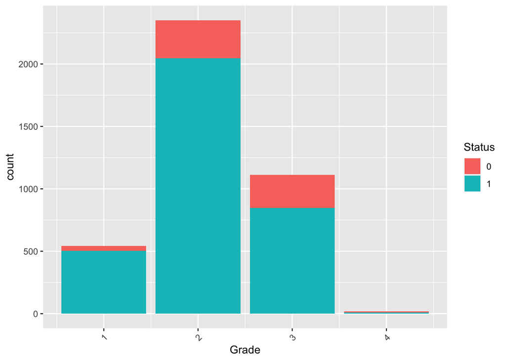

```r
df_cancer %>% ggplot(aes(Grade, fill = Status)) + geom_bar() +
  theme(axis.text.x = element_text(angle = 45, hjust = 1))
```

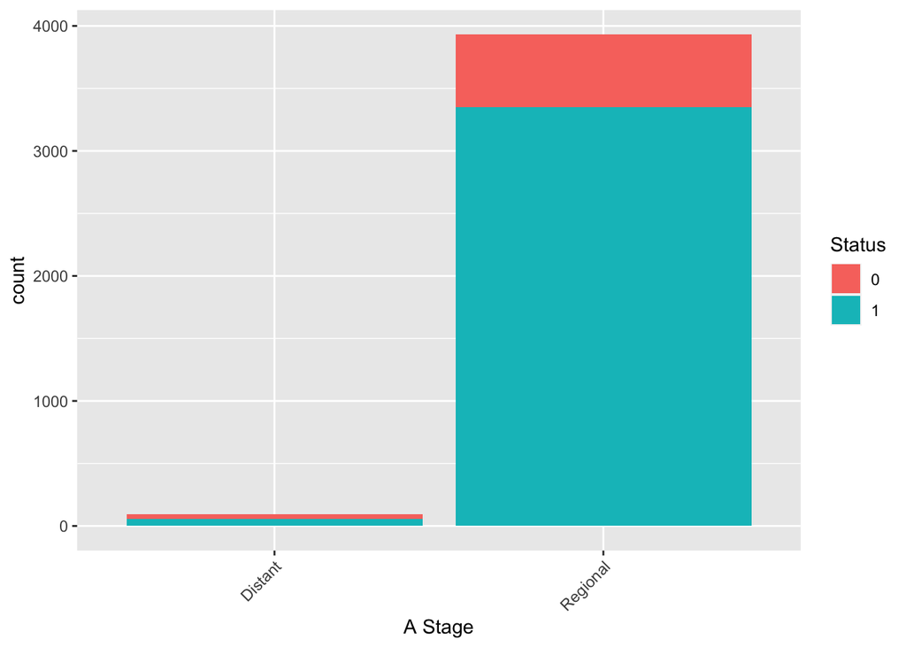

```r
df_cancer %>% ggplot(aes(`A Stage`, fill = Status)) + geom_bar() +
  theme(axis.text.x = element_text(angle = 45, hjust = 1))
```

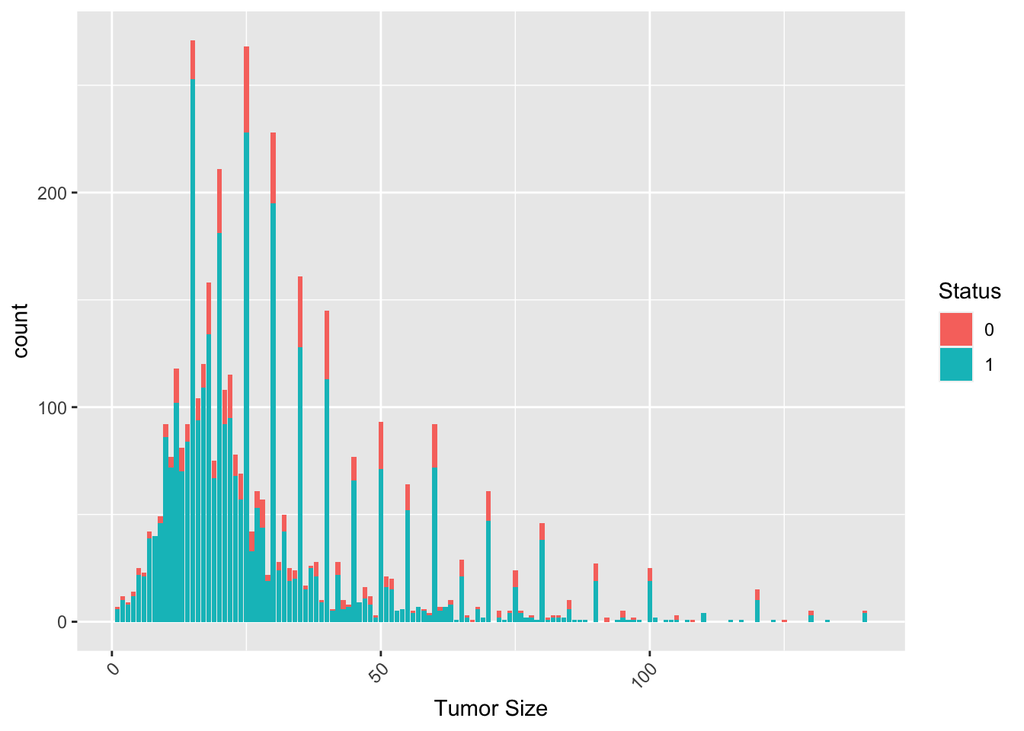

```r
df_cancer %>% ggplot(aes(`Tumor Size`, fill = Status)) + geom_bar() +
  theme(axis.text.x = element_text(angle = 45, hjust = 1))
```

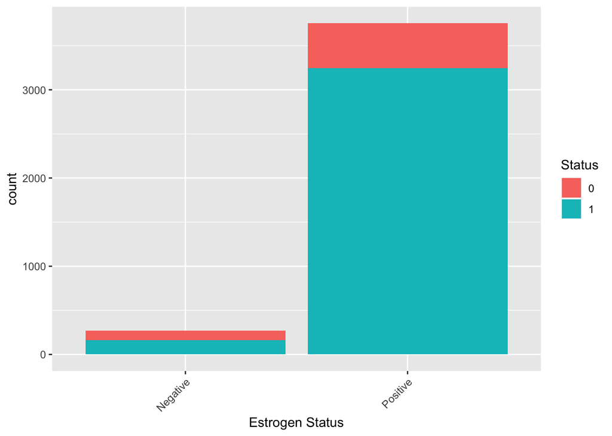

```r
df_cancer %>% ggplot(aes(`Estrogen Status`, fill = Status)) + geom_bar() +
  theme(axis.text.x = element_text(angle = 45, hjust = 1))
```

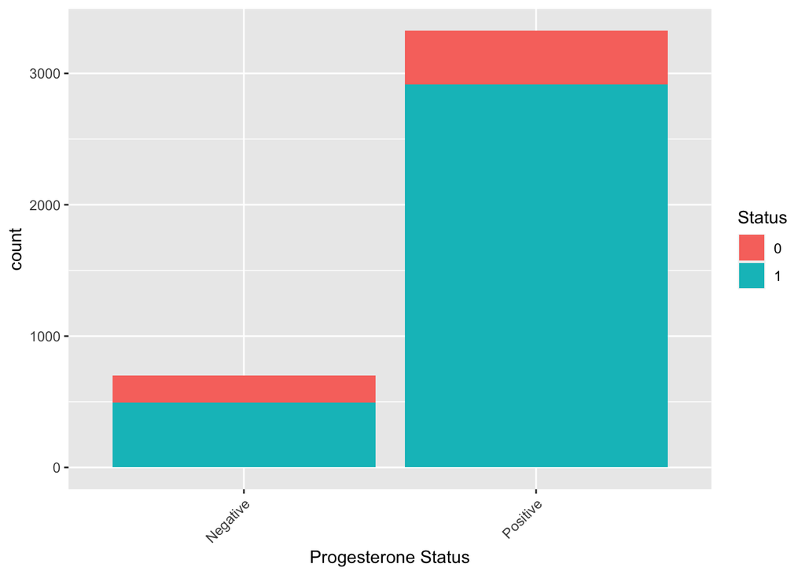

```r
df_cancer %>% ggplot(aes(`Progesterone Status`, fill = Status)) +
  geom_bar() + theme(axis.text.x = element_text(angle = 45, hjust = 1))
```

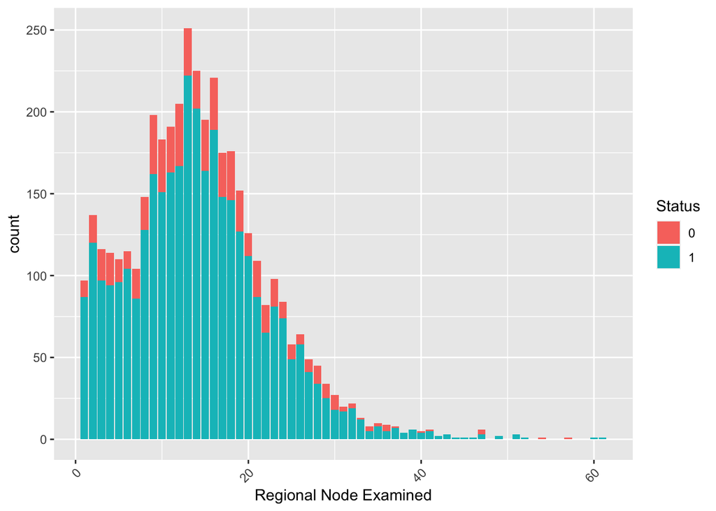

```r
df_cancer %>% ggplot(aes(`Regional Node Examined`, fill = Status)) +
  geom_bar() + theme(axis.text.x = element_text(angle = 45, hjust = 1))
```

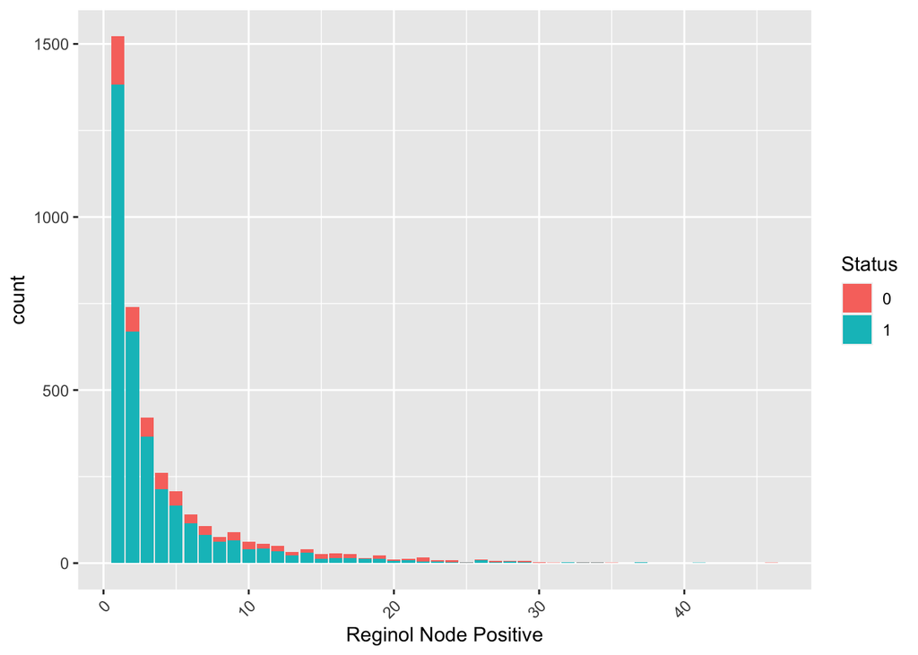

```r
df_cancer %>% ggplot(aes(`Reginol Node Positive`, fill = Status)) +
  geom_bar() + theme(axis.text.x = element_text(angle = 45, hjust = 1))
```

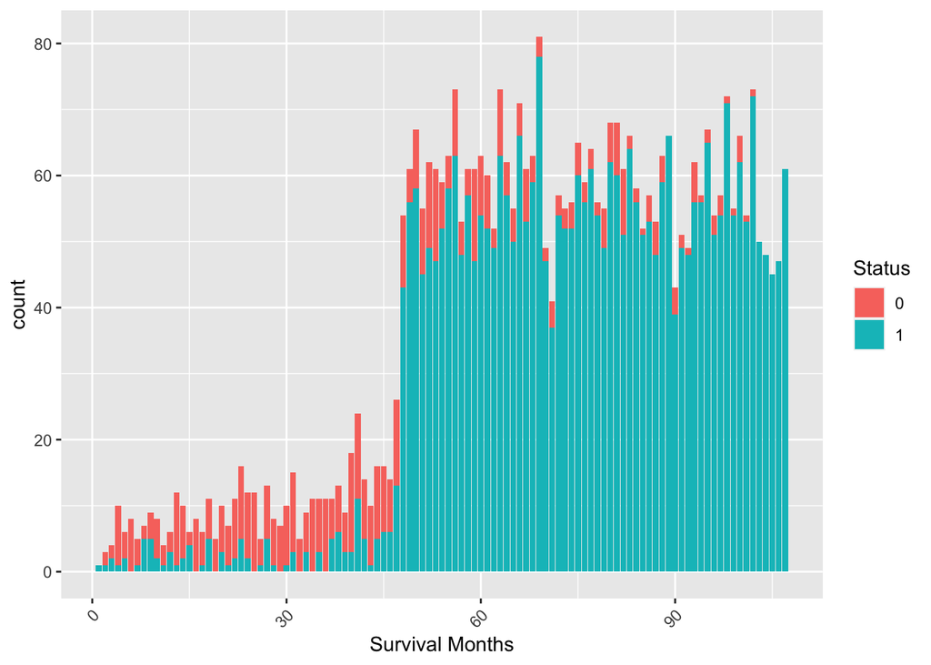

```r
df_cancer %>% ggplot(aes(`Survival Months`, fill = Status)) + geom_bar() +
  theme(axis.text.x = element_text(angle = 45, hjust = 1))
```

**Boxplot donde se tamaño del tumor para cada estado**

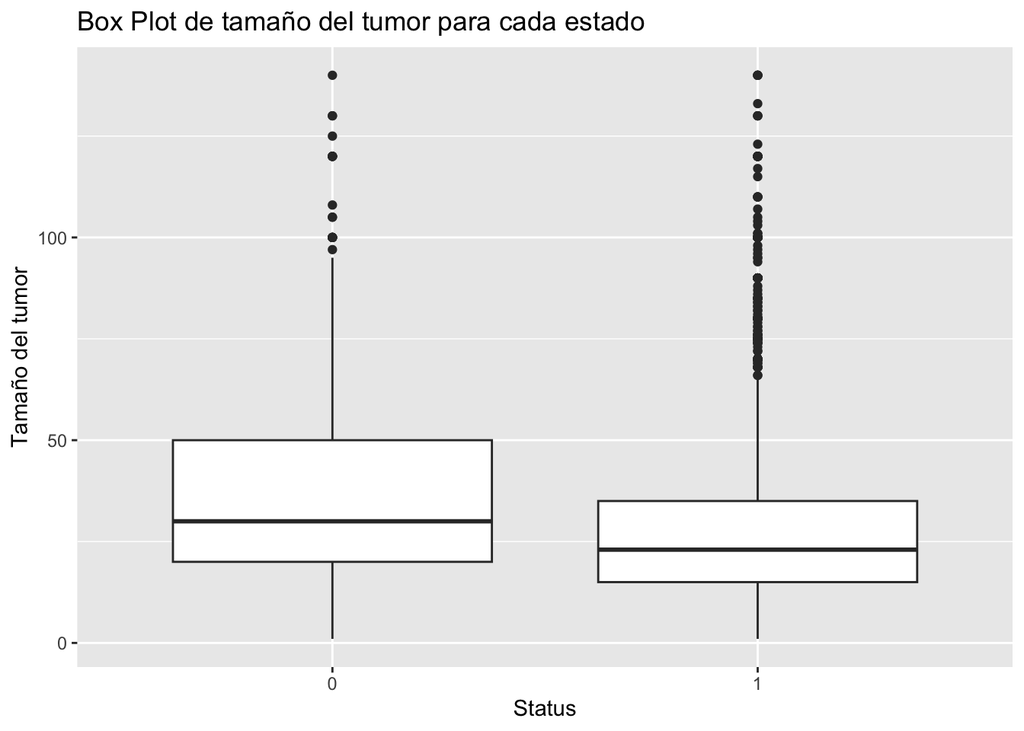

```r
ggplot(df_cancer, aes(Status, `Tumor Size`)) + geom_boxplot() +
  ylab("Tamaño del tumor") +
  ggtitle("Box Plot de tamaño del tumor para cada estado")
```

Se observa que las que no han sobrevivo al cáncer tenían un tamaño de tumor mayor en promedio.

**Distribución según tamaño y edad para el estado de la paciente de cáncer**

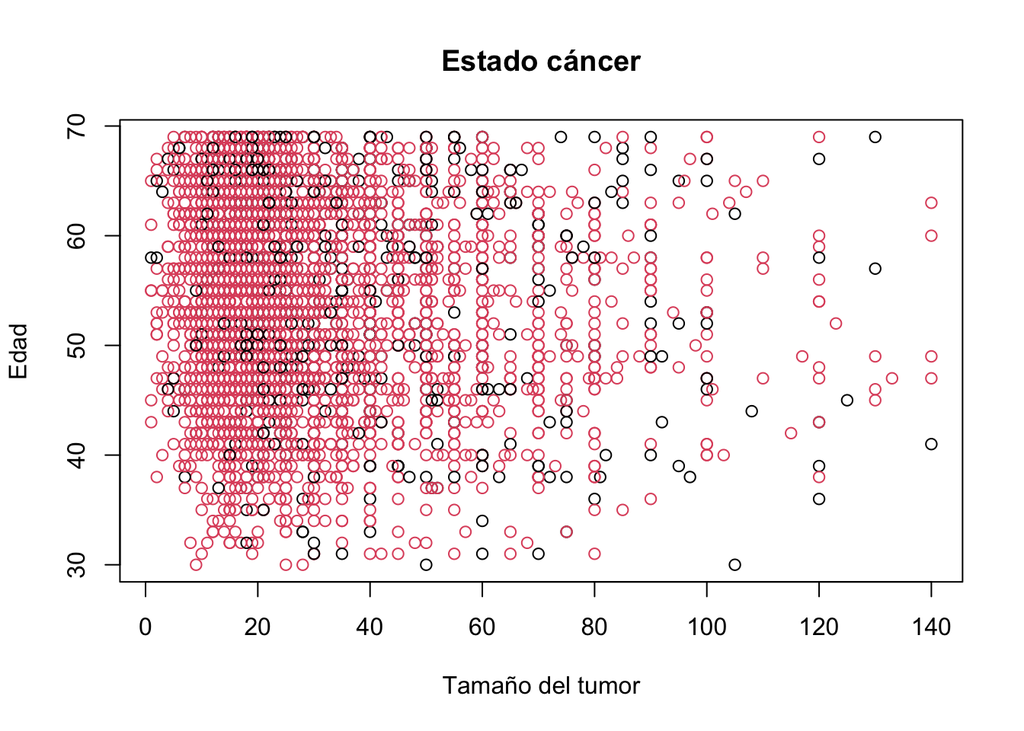

```r
plot(x = df_cancer$`Tumor Size`, y = df_cancer$Age, col = df_cancer$Status,
     main = "Estado cáncer", xlab = "Tamaño del tumor", ylab = "Edad")
```

**Gráfico de tarta donde se muestra si el tumor se ha extendido o no**

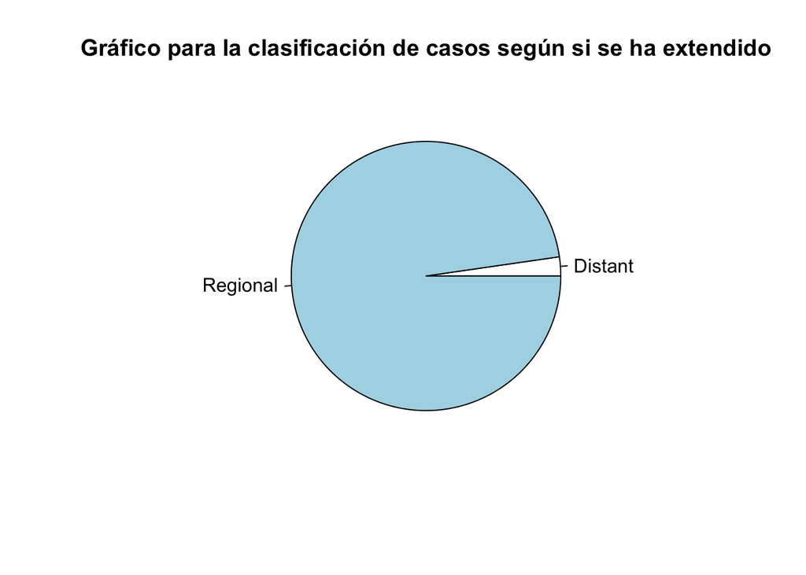

```r
pie(table(df_cancer$`A Stage`),
    main = "Gráfico para la clasificación de casos según si se ha extendido")
```

*Conclusiones*: Se puede observar que la mayoría de las pacientes han sobrevivo después de tener el cáncer, aunque las que tenían el cáncer ya muy avanzado han sobrevivido pocos meses, así como las que tenían un mayor tamaño de tumor. La mayoría de los casos estudiados corresponden a mujeres blancas, casadas y con cáncer en grado 2. La mayoría tenía el cáncer poco extendido.